# R Notebook

#### Versuchen Sie die Leser aus dem Buch-Datenset zu clustern: Welche Bücher gehören in welches Cluster?

* Laden von libraries

```r
library(tidyverse)
library(tidyverse)
library(cluster)
library(caret)
```

* Datensatz importieren

```r
all <- read_csv("C:/Users/julia/Desktop/Wahlpflicht-Data Science/Hausaufgaben_Data_Science/all3.csv",
    col_types = cols(Age = col_double()))
```

* Im ersten Schritt wird die zugeordnete Klasse entfernt.

- Im zweiten wurden Titel, Rating und User id selektiert.
- Anschließend habe ich diese Spalten umbenannt, um damit besser arbeiten zu können (konnte davor die Spalten auch mit ’’ nicht ansprechen)

```r
all_sel2 <- all_sel %>%
  select( 'Book-Title',  'Book-Rating', 'User-ID') %>%
  rename(rating='Book-Rating', title='Book-Title', id='User-ID') %>%
  replace_na(rating ="keine Angabe")
```

```
Fehler: 1 components of `...` were not used.

We detected these problematic arguments:
* `rating`

Did you misspecify an argument?
Run `rlang::last_error()` to see where the error occurred.
```

```r
all <- all_sel2 %>%
  group_by(id)
```

[output not shown]

* Nachdem der Basis Cleaning gemacht wurde, kann man mit dem Clustering beginnen.

- zuerst wird eine neue Variable definiert (i=1). Damit wird gezeigt welcher User wie viele Bewertungen abgegeben hat. Z.B. bei einem User steht eine 1 bei 20 Bewertungen und überall sonst eine 0. So hat der User 20 Bewertungen abgegeben.

```r
select4<-select4%>%
  mutate(i=1) %>%
  spread(id, i, fill=0)
```

```
Fehler: Must extract column with a single valid subscript.
x Subscript `var` has the wrong type `function`.
i It must be numeric or character.
Run `rlang::last_error()` to see where the error occurred.
```

- Zuerst habe ich bestimmt ,dass die Zahlen ausgeschrieben werden.
- Danach wurde ein Scree-Test durgeführt, um zu wissen, wie viele k sinnvoll wären.
- Der Knick in der Kurve bedeutet, die Variabilität der Cluster.(In diesem Fall k= 2)

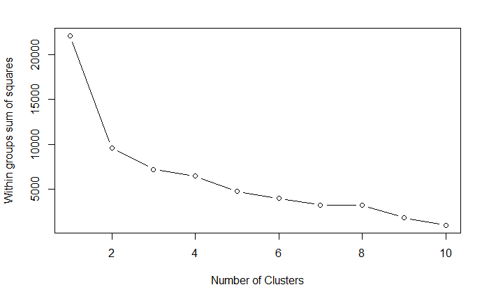

- Nun wird Clustering mit k=2 versucht.

# Hier kriege ich bedauerlicherweise einen Fehler, den ich nicht lösen konnte.

```r
clusplot(all, k.means.fit$cluster, color=TRUE, shade=TRUE,
labels=2, lines=0, main="K-means cluster plot")
```

```
Fehler in princomp.default(x, scores = TRUE, cor = ncol(x) > 2) :
  'princomp' can only be used with more units than variables
```

- Hier wurde die euklidische Distanz berechnet

```r
(select4.dist <- dist(scale(all), method="euclidean"))
```

```
            1          2          3          4          5
2  222.135096
3  106.883134 194.812733
4  159.499380 227.964994 118.524372
5  106.958255 194.853925   6.930973 118.591741
6  188.000343 248.741043 154.764616 194.853835 154.816051
7  165.360845 232.103813 126.301835 173.112831 126.364704
8  146.643240 219.162517 100.559337 155.332122 100.638225
9  152.316358 222.998296 108.665583 160.698744 108.738532
10 107.034319 194.895634   8.017042 118.659719   8.950231
11 151.262918 222.280063 107.183884 159.700373 107.257541
12 106.886486 194.814441   5.710882 118.525883   6.953091
13 106.961569 194.855641   6.976132 118.593535   8.024022
14 106.902286 194.822913   5.986532 118.537865   7.149073
15 106.926246 194.835892   6.389818 118.557522   7.463497
16 107.452466 195.125157  12.394478 119.032083  12.978671
            6          7          8          9         10
2
3
4
5
6
7  199.679768
8  184.477687 161.344356
9  189.018588 166.517279 147.945940
10 154.867854 126.427913 100.717474 108.811784
11 188.170419 165.553774 146.860609 152.525495 107.331308
12 154.765112 126.301835 100.559082 108.665112   8.004264
13 154.816901 126.365265 100.638728 108.738811   8.949099
14 154.773297 126.310952 100.570152 108.675003   8.127995
15 154.787498 126.327569 100.590691 108.693707   8.366466
16 155.151172 126.772811 101.149244 109.210786  13.514976
           11         12         13         14         15
2
3
4
5
6
7
8
9
10
11
12 107.182212
13 107.256880   6.928280
14 107.190449   5.777706   7.021836
15 107.207871   6.065186   7.255664   5.746711
16 107.731884  12.221909  12.853977  12.054301  12.000711
```

- Die erhaltenen Daten kann man in einem Plot gut visualisieren.

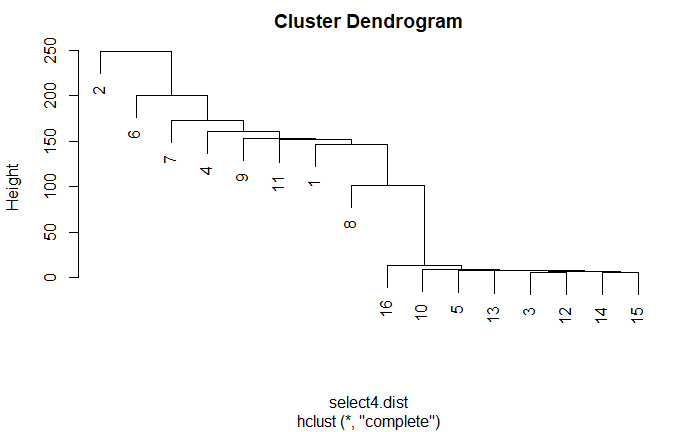

*** Noch ein Versuch ein Cluster abzubilden, aber diesmal nicht mit id´s der Nutzer, sondern mit Titeln der Bücher.

```r
all_<-all_sel3%>%
  mutate(i=1) %>%
  spread(id, i, fill=0)
```

```
Fehler: Must extract column with a single valid subscript.
x Subscript `var` has the wrong type `function`.
i It must be numeric or character.
Run `rlang::last_error()` to see where the error occurred.
```

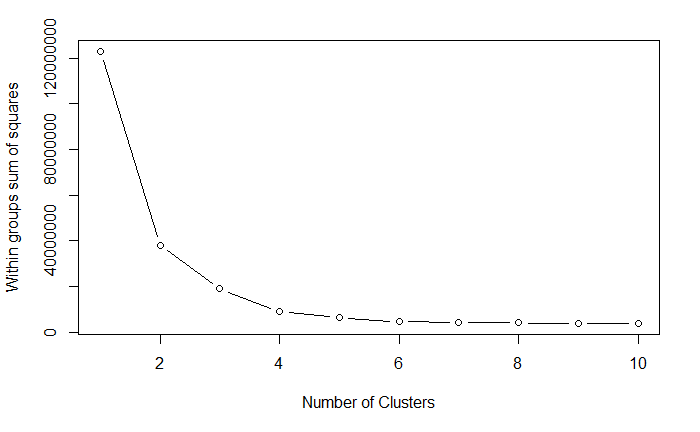

** Der Fehler ist, leider, immer noch da! :(

```r
clusplot(all_, k.means.fit2$cluster, color=TRUE, shade=TRUE,
labels=2, lines=0, main="K-means cluster plot")
```

```
Fehler in princomp.default(x, scores = TRUE, cor = ncol(x) > 2) :
  'princomp' can only be used with more units than variables
```

```r
(select4.dist2 <- dist(scale(all_), method="euclidean"))
```

[output not shown]

[output cut: 66 more lines]

[output not shown]

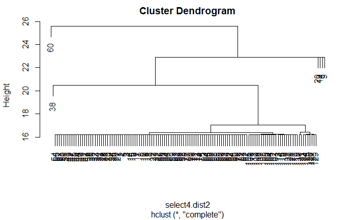